# Estimación Áreas Pequeñas por Municipios - Puntaje Matemáticas PRESABER

## 4. Resultados

Luego de realizar todos los posibles modelos 128 en total, se creo una tabla con los resultados. La media de los coeficientes de variación y la desviación estándar de todos los modelos y las variables utilizadas. A continuación se muestran los primeros 15 registros.

| Var_x1 | Var_x2 | Var_x3 | Var_x4 | Mean_cves | sd_cves |
| --- | --- | --- | --- | --- | --- |
| LECTURA_CRITICA_PUNT | FINS_ESTRATOVIVIENDAENERGIA | CALENDARIO | PERS_GENERO | 2.84919215481211 | 0.297490542947928 |
| LECTURA_CRITICA_PUNT | FINS_ESTRATOVIVIENDAENERGIA | CALENDARIO | FINS_PERSONASHOGARACTUAL | 2.87645782974248 | 0.299216138938939 |
| LECTURA_CRITICA_PUNT | FINS_ESTRATOVIVIENDAENERGIA | CALENDARIO | FINS_CUARTOSHOGARACTUAL | 2.86702765560452 | 0.299227150165514 |
| LECTURA_CRITICA_PUNT | FINS_ESTRATOVIVIENDAENERGIA | CALENDARIO | FINS_PISOSHOGAR | 2.939776596166 | 0.268945945272329 |
| LECTURA_CRITICA_PUNT | FINS_ESTRATOVIVIENDAENERGIA | CALENDARIO | FINS_TIENEINTERNET | 2.9652889334362 | 0.303681921747304 |
| LECTURA_CRITICA_PUNT | FINS_ESTRATOVIVIENDAENERGIA | CALENDARIO | FINS_TIENECOMPUTADOR | 2.93691049066142 | 0.296702045975367 |
| LECTURA_CRITICA_PUNT | FINS_ESTRATOVIVIENDAENERGIA | CALENDARIO | FINS_TIENEAUTOMOVILPARTICULAR | 2.77749907018884 | 0.282774246511851 |
| LECTURA_CRITICA_PUNT | FINS_ESTRATOVIVIENDAENERGIA | CALENDARIO | INGLES_DESEM | 2.43389462276889 | 0.238441782714181 |
| LECTURA_CRITICA_PUNT | FINS_ESTRATOVIVIENDAENERGIA | NATURALEZA | PERS_GENERO | 2.79227647039098 | 0.292954791635255 |
| LECTURA_CRITICA_PUNT | FINS_ESTRATOVIVIENDAENERGIA | NATURALEZA | FINS_PERSONASHOGARACTUAL | 2.84874657775113 | 0.295908492897537 |
| LECTURA_CRITICA_PUNT | FINS_ESTRATOVIVIENDAENERGIA | NATURALEZA | FINS_CUARTOSHOGARACTUAL | 2.8380080610778 | 0.296252790015277 |
| LECTURA_CRITICA_PUNT | FINS_ESTRATOVIVIENDAENERGIA | NATURALEZA | FINS_PISOSHOGAR | 2.90337841870045 | 0.262923440798794 |
| LECTURA_CRITICA_PUNT | FINS_ESTRATOVIVIENDAENERGIA | NATURALEZA | FINS_TIENEINTERNET | 2.91850033289385 | 0.299808551281862 |
| LECTURA_CRITICA_PUNT | FINS_ESTRATOVIVIENDAENERGIA | NATURALEZA | FINS_TIENECOMPUTADOR | 2.89587883090683 | 0.291657086304204 |
| LECTURA_CRITICA_PUNT | FINS_ESTRATOVIVIENDAENERGIA | NATURALEZA | FINS_TIENEAUTOMOVILPARTICULAR | 2.73165191266699 | 0.273851900838827 |

<sup>1</sup> Primeros 15 registros

Las medias de los coeficientes de variación tienen la siguiente distribución y se observa que el modelo número 80 es el de menor media en los cve.

```
##    Min. 1st Qu.  Median    Mean 3rd Qu.    Max.
##   1.105   1.975   2.728   2.389   2.856   3.092
```

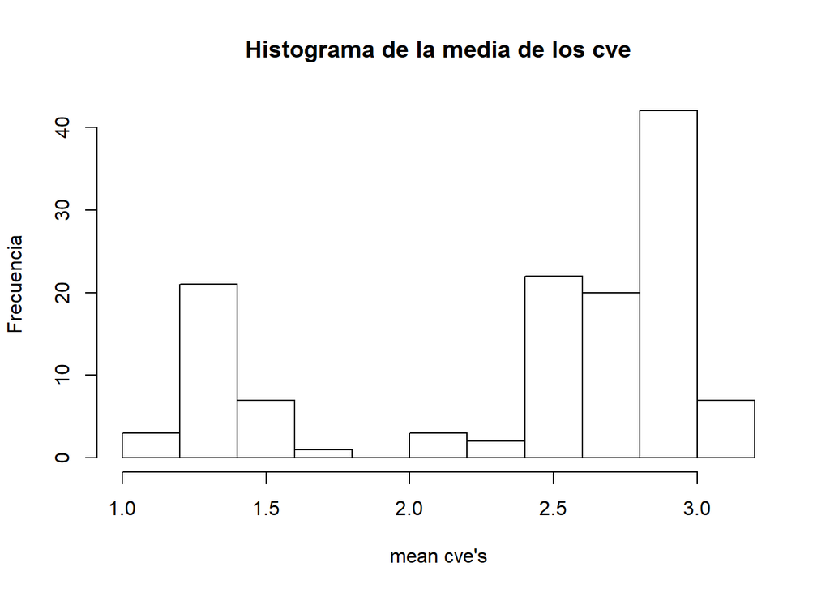

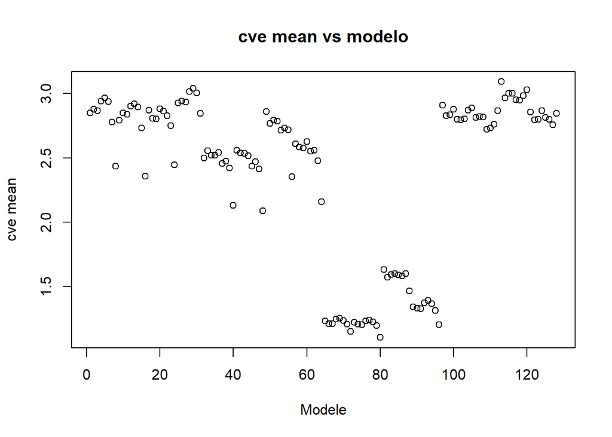

El modelo con menor media de coeficiente de variación y menor desviación estándar es:

|  | Var_x1 | Var_x2 | Var_x3 | Var_x4 | Mean_cves | sd_cves |
| --- | --- | --- | --- | --- | --- | --- |
| 80 | CIENCIAS_NATURALES_PUNT | FINS_ESTRATOVIVIENDAENERGIA | NATURALEZA | INGLES_DESEM | 1.10477788780478 | 0.0910159091704593 |

<sup>1</sup> Mejor Modelo

## 5. Conclusiones

El modelo que mejor describe el puntaje de matemáticas por medio de estimación HBF tiene las siguientes variables auxiliares:

- Puntaje de ciencias naturales.
- Estrato vivienda en energia.
- Naturaleza del colegio (Oficial y No Oficial)
- Desempeño en ingles (A-, A1, A2, B1, B+)

La media de los coeficientes de variación de todos los municipios es 1.10 y la desviación estándar de esta es 0.09, lo que permite obtener unos resultados muy confiables para estimar el puntaje de matemáticas en todos los municipios.

2018-03 Realizado por: Nestor Jardany Serrano Rojas

Copyright © All rights reserved.